# Introduction to Biostatistics

# 1 Learning objectives

## 1.1 Learning objectives

- Understand the different **types** of variables that can be measured
- Think about variables in terms of **central tendency** or **location**
- Think about variables in terms of **dispersion** or **spread**
- Start to think about variable **distributions** and **plots**

# 2 Types of variables

## 2.1 Types of variables

- There are a lot of ways to talk about variables
  - Continuous vs categorical
  - Quantitative vs qualitative
  - Numeric vs non-numeric
- Often loose, ambiguous, and arbitrary

## 2.2 Levels of measurement

- Four **ordered** levels of measurement based on the **mathematical** operations that can be performed
  - Nominal
  - Ordinal
  - Interval
  - Ratio

> Stevens, S. S. (1946). On the theory of scales of measurement. Science, 103(2684), 677-680.

## 2.3 Nominal variables

- **Categories** with **no intrinsic ordering**
  - Nominal = “name”
- Examples
  - Department: Psychology, Epidemiology, Statistics, Business
  - Religion: Christian, Jewish, Muslim, Atheist
  - Ice cream flavor: vanilla, chocolate, strawberry

## 2.4 Ordinal variables

- **Categories** with **some intrinsic ordering**
  - Ordinal = “ordered”
  - Differences between categories are **not meaningful/equal**
- Examples
  - Dose of treatment: low, medium, high
  - Rankings: 1st, 2nd, 3rd, 4th
  - Education: high school, some college, college grad, graduate
  - Likert scales: agree, neutral, disagree

## 2.5 Interval variables

- **Quantitative variables** with **no meaningful 0 point**
  - (“Meaningful 0”: value of 0 = nothing)
  - **Differences** between values are meaningful but **ratios** are not!
- Example: Temperature in Fahrenheit or Celsius
  - **Difference** from 100F to 90F = **difference** from 90F to 80F
  - But 100F is **not twice** 50F (because 0F is arbitrary)
- Most “continuous” variables you deal with are **interval**
  - Most statistical procedures assume interval-level measurement

## 2.6 Ratio variables

- **Quantitative variables** with **meaningful 0 point**
  - (“Meaningful 0”: value of 0 = nothing)
  - **Differences** between values are meaningful and so are **ratios**!
- Example: Temperature in Kelvin
  - **Difference** from 100K to 90K = **difference** from 90K to 80K
  - 100K is **twice as hot** as 50K (0K is *zero* molecular movement)
- Height, weight, age, counts

## 2.7 Stevens (1946)

The *levels of measurement* determine what **mathematical** (and **statistical**) operations you can perform

| Mathematical operation | Nominal | Ordinal | Interval | Ratio |
| --- | --- | --- | --- | --- |
| equal, not equal | $\checkmark$ | $\checkmark$ | $\checkmark$ | $\checkmark$ |
| greater or less than |  | $\checkmark$ | $\checkmark$ | $\checkmark$ |
| add, subtract |  |  | $\checkmark$ | $\checkmark$ |
| multiply, divide |  |  |  | $\checkmark$ |
| central tendency | mode | median | mean | mean |

## 2.8 **R** “translations” of variable types

- Nominal
  - `char` = “character”: Text variable, also called “string”
- Nominal or ordinal
  - `fctr` = “factor”: Ordered or unordered categories
  - `log` = “logical” or “boolean”: `TRUE` or `FALSE`
- Interval or ratio
  - `int` = “integer”: Whole number (no decimals)
  - `dbl` = “double” (`num`): Number w possible decimal places

# 3 Central tendency

## 3.1 Central tendency

- Also called “location”
  - Where are the observations *located*?
- Several measures of central tendency
  - Depend on scale type
  - Mode, median, mean

## 3.2 Mode

- The most frequently occurring value
  - Value actually exists in the data
- Used for *nominal*, *ordinal*
  - Can also be used for *interval*, and *ratio* variables but less useful

## 3.4 Mean

- Add up all observations and divide by the number of observations
  - *Value may not actually occur in the data*
- Mathematically: $\frac{\sum_{i=1}^n X_i}{n}$
- Used for *interval* and *ratio* variables

## 3.5 **gapminder** dataset

```r
gap <- gapminder
head(gap)
```

```
# A tibble: 6 × 6
  country     continent  year lifeExp      pop gdpPercap
  <fct>       <fct>     <int>   <dbl>    <int>     <dbl>
1 Afghanistan Asia       1952    28.8  8425333      779.
2 Afghanistan Asia       1957    30.3  9240934      821.
3 Afghanistan Asia       1962    32.0 10267083      853.
4 Afghanistan Asia       1967    34.0 11537966      836.
5 Afghanistan Asia       1972    36.1 13079460      740.
6 Afghanistan Asia       1977    38.4 14880372      786.
```

## 3.6 **gapminder** variables

| Variable | R variable type | Scale type |
| --- | --- | --- |
| `country` | factor | nominal |
| `continent` | factor | nominal |
| `year` | integer | ordinal / interval |
| `lifeExp` | double / numeric | ratio |
| `pop` | integer | ratio (count) |
| `gdpPercap` | double / numeric | ratio |

## 3.7 Nominal variables: Mode

- `Mode()` function from **DescTools** package

```r
Mode(gap$country)
```

```
  [1] Afghanistan              Albania                  Algeria
  [4] Angola                   Argentina                Australia
  [7] Austria                  Bahrain                  Bangladesh
 [10] Belgium                  Benin                    Bolivia
 [13] Bosnia and Herzegovina   Botswana                 Brazil
 [16] Bulgaria                 Burkina Faso             Burundi
 [19] Cambodia                 Cameroon                 Canada
 [22] Central African Republic Chad                     Chile
 [25] China                    Colombia                 Comoros
 [28] Congo, Dem. Rep.         Congo, Rep.              Costa Rica
 [31] Cote d'Ivoire            Croatia                  Cuba
 [34] Czech Republic           Denmark                  Djibouti
 [37] Dominican Republic       Ecuador                  Egypt
 [40] El Salvador              Equatorial Guinea        Eritrea
 [43] Ethiopia                 Finland                  France
```

[output cut: 36 more lines]

- There is *no single mode* for `country`

## 3.8 Nominal variables: Mode

- `Mode()` function from **DescTools** package

```r
Mode(gap$continent)
```

```
[1] Africa
attr(,"freq")
[1] 624
Levels: Africa Americas Asia Europe Oceania
```

- There are 52 countries (52 countries * 12 years = 624) in Africa
  - The value of “Africa” is the **mode** of the `continent` variable

## 3.9 Ordinal variables: Median

```r
median(gap$year, na.rm = TRUE)
```

```
[1] 1979.5
```

- 1952, 1957, 1962, 1967, 1972, 1977, 1982, 1987, 1992, 1997, 2002, 2007
  - Median is halfway between 1977 and 1982
- `na.rm = TRUE` option removes missing values
  - If you have missing values and don’t include this, you will get `NA`

## 3.10 Interval variables: Mean

```r
mean(gap$year, na.rm = TRUE)
```

```
[1] 1979.5
```

- $(1952 + 1957 + \dots + 2002 + 2007)/12$
- You can also calculate the median of an interval variable, but we just did that for this variable (treating it as ordinal)
- `na.rm = TRUE` option removes missing values
  - If you have missing values and don’t include this, you will get `NA`

## 3.11 Use only data from 2007

- Including all data gives us a confusing mish-mash of information
  - I’m just going to include data from 2007 for these variables
- Also going to create the `gdp` variable at the same time

```r
gap_2007 <- gapminder %>%
  mutate(gdp = gdpPercap * pop) %>%
  filter(year == 2007)
```

## 3.12 Ratio variables: Median

```r
median(gap_2007$lifeExp, na.rm = TRUE)
```

```
[1] 71.9355
```

```r
median(gap_2007$pop, na.rm = TRUE)
```

```
[1] 10517531
```

```r
median(gap_2007$gdpPercap, na.rm = TRUE)
```

```
[1] 6124.371
```

```r
median(gap_2007$gdp, na.rm = TRUE)
```

```
[1] 57869055458
```

- 50% of countries have a life expectancy **less than** 71.9355 years
- 50% of countries have a life expectancy **greater than** 71.9355 years

## 3.13 Ratio variables: Mean

```r
mean(gap_2007$lifeExp, na.rm = TRUE)
```

```
[1] 67.00742
```

```r
mean(gap_2007$pop, na.rm = TRUE)
```

```
[1] 44021220
```

```r
mean(gap_2007$gdpPercap, na.rm = TRUE)
```

```
[1] 11680.07
```

```r
mean(gap_2007$gdp, na.rm = TRUE)
```

```
[1] 409220666999
```

- The average life expectancy is 67.00742 years

## 3.14 Compare mean and median

- Mean and median are both measures of *central tendency* for numbers
  - **What does it mean when they differ?**
- Median involves only values near it
  - Extreme values don’t impact it
- Mean involves **all** values
  - **Extreme values impact the mean**
  - Mean is “pulled toward” extreme values

## 3.15 Mean and median of `lifeExp`

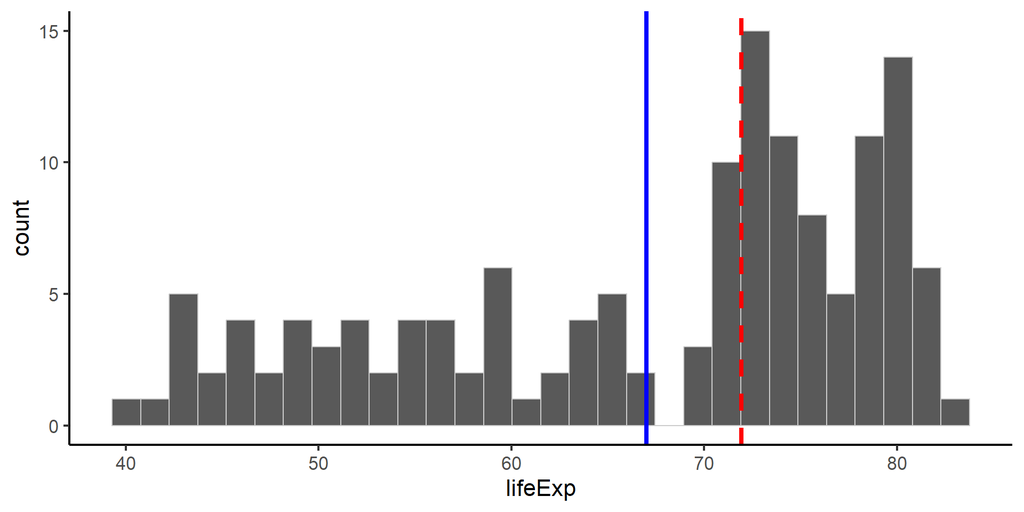

```r
ggplot(data = gap_2007, aes(x = lifeExp)) +
  geom_histogram(bins = 30, color = "grey80") +
  geom_vline(xintercept = mean(gap_2007$lifeExp), color = "blue", linewidth = 1.5) +
  geom_vline(xintercept = median(gap_2007$lifeExp), color = "red", linewidth = 1.5, linetype = "dashed")
```

## 3.16 Mean and median of `pop`

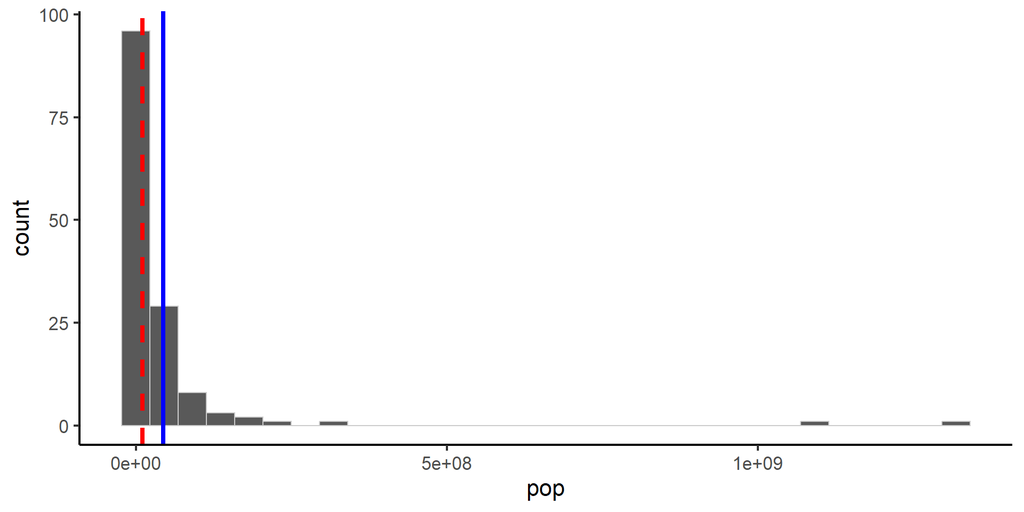

```r
ggplot(data = gap_2007, aes(x = pop)) +
  geom_histogram(bins = 30, color = "grey80") +
  geom_vline(xintercept = mean(gap_2007$pop), color = "blue", linewidth = 1.5) +
  geom_vline(xintercept = median(gap_2007$pop), color = "red", linewidth = 1.5, linetype = "dashed")
```

## 3.17 Mean and median of `gdpPercap`

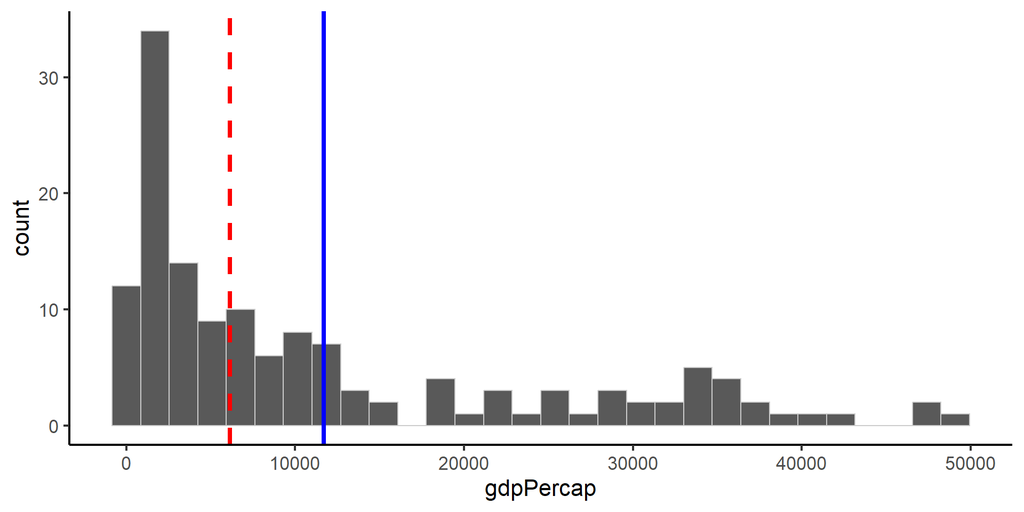

```r
ggplot(data = gap_2007, aes(x = gdpPercap)) +
  geom_histogram(bins = 30, color = "grey80") +
  geom_vline(xintercept = mean(gap_2007$gdpPercap), color = "blue", linewidth = 1.5) +
  geom_vline(xintercept = median(gap_2007$gdpPercap), color = "red", linewidth = 1.5, linetype = "dashed")
```

# 4 Dispersion

## 4.1 Dispersion

- Also called “spread”
  - How spread out or *dispersed* are the observations?
  - Only applies to numeric (interval or ratio) variables
- Several measures of dispersion
  - Depend on scale type and variable distribution
  - Minimum and maximum, percentiles, standard deviation

## 4.2 Minimum and maximum

- Minimum

```r
min(gap_2007$lifeExp, na.rm = TRUE)
```

```
[1] 39.613
```

```r
min(gap_2007$pop, na.rm = TRUE)
```

```
[1] 199579
```

```r
min(gap_2007$gdpPercap, na.rm = TRUE)
```

```
[1] 277.5519
```

- Maximum

```r
max(gap_2007$lifeExp, na.rm = TRUE)
```

```
[1] 82.603
```

```r
max(gap_2007$pop, na.rm = TRUE)
```

```
[1] 1318683096
```

```r
max(gap_2007$gdpPercap, na.rm = TRUE)
```

```
[1] 49357.19
```

## 4.3 Percentiles

- Value **below which** some percentage of observations lie
  - 67th percentile: 67% of observations have values below this value
  - Median is the 50th percentile: 50% below (and 50% above)
  - Quartiles divide into 4 parts: 25th, 50th, 75th percentiles
  - Standardized tests: 97th percentile means you scored higher than 97% of people taking the test

## 4.4 Percentiles

```r
quantile(gap_2007$lifeExp, c(0.25, 0.5, 0.75))
```

```
     25%      50%      75%
57.16025 71.93550 76.41325
```

```r
quantile(gap_2007$pop, c(0.25, 0.5, 0.75))
```

```
     25%      50%      75%
 4508034 10517531 31210042
```

```r
quantile(gap_2007$gdpPercap, c(0.1, 0.9))
```

```
       10%        90%
  887.2871 33644.0530
```

## 4.5 Standard deviation (& variance)

- Spread around the mean
- Same units as the variable
  - Unlike variance, with is $SD^2$
- Influenced by extreme values
- Mathematically: $\sqrt{\frac{\sum (X_i - \overline{X})^2}{n-1}}$

## 4.6 Presenting location & dispersion

- Symmetric distribution
  - Mean $\pm$ standard deviation
  - Median (25th to 75th percentile)
  - Median (min, max)
- Asymmetric distribution
  - Median (25th to 75th percentile)
  - Median (min, max)

## 4.7 Presenting

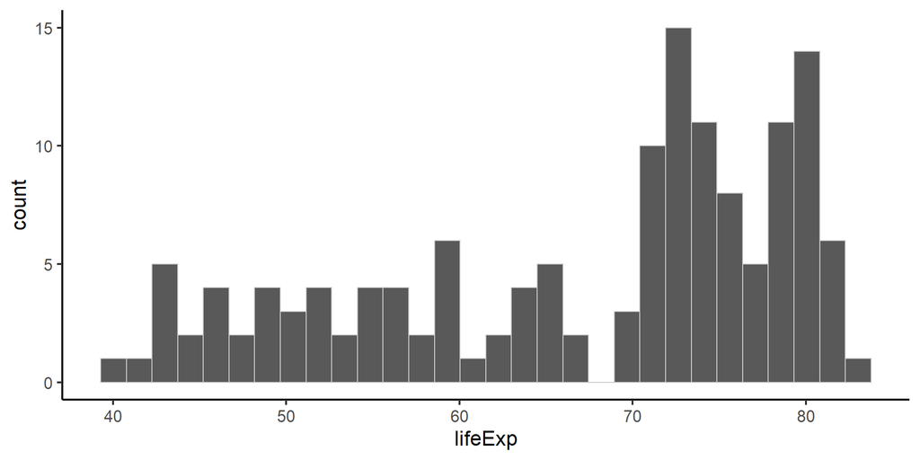

```r
lifeexp_perc <- quantile(gap_2007$lifeExp, c(0, 0.25, 0.5, 0.75, 1))
lifeexp_sd <- sd(gap_2007$lifeExp, na.rm = TRUE)
lifeexp_mean <- mean(gap_2007$lifeExp, na.rm= TRUE)
ggplot(data = gap_2007, aes(x = lifeExp)) +
  geom_histogram(bins = 30, color = "grey80")
```

## 4.8 Presenting: Mean plus/minus 1 SD

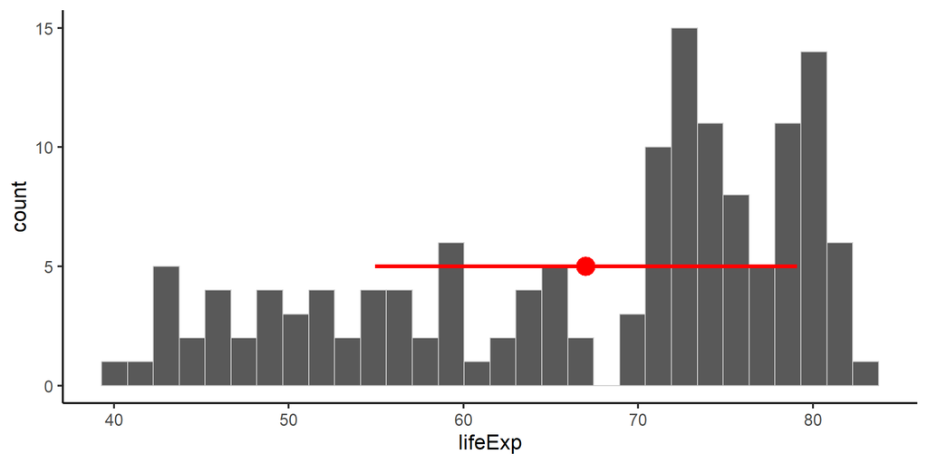

```r
ggplot(data = gap_2007, aes(x = lifeExp)) +
  geom_histogram(bins = 30, color = "grey80") +
  annotate("pointrange", x = lifeexp_mean, y = 5,
            xmin = mean(gap_2007$lifeExp) - lifeexp_sd,
            xmax = mean(gap_2007$lifeExp) + lifeexp_sd,
            size = 1.5, linewidth = 1.5, color = "red") +
  ylab("count")
```

## 4.9 Presenting: Median, 25th, 75th %iles

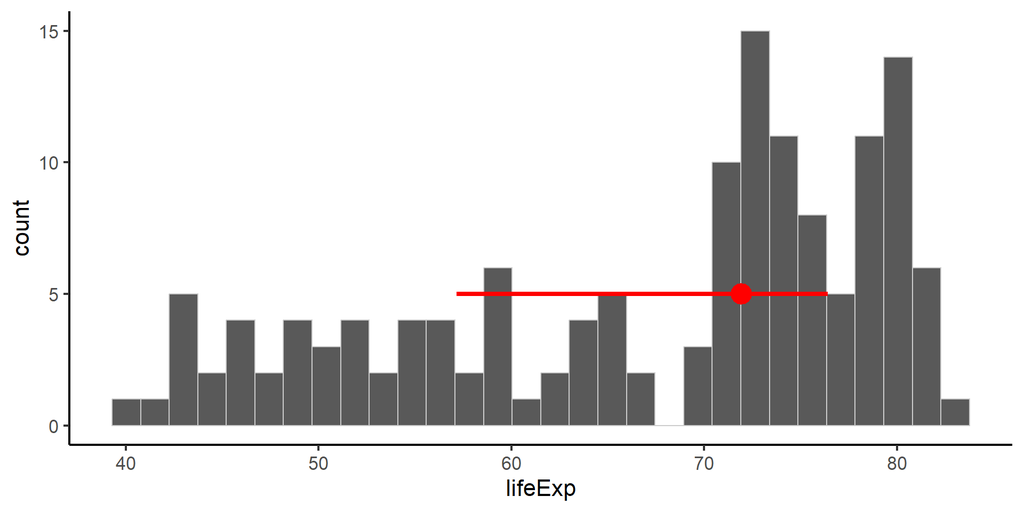

```r
ggplot(data = gap_2007, aes(x = lifeExp)) +
  geom_histogram(bins = 30, color = "grey80") +
  annotate("pointrange", x = lifeexp_perc[3], y = 5,
            xmin = lifeexp_perc[2],
            xmax = lifeexp_perc[4],
            size = 1.5, linewidth = 1.5, color = "red") +
  ylab("count")
```

# 5 In-class activities

## 5.1 In-class activities

- Look at some data and **variables**
  - Think about what **type(s)** of variables they are
- Examine **central tendency** and **dispersion** for the variables
  - Present the **best values** to describe the data
- Start to think about variable **distributions** and **plots**